# transcripts_under_notch1

### Victor Ulises Plascencia Pérez

## Abstract

En este reporte se describen resultados de un análisis de expresión diferencial utilizando datos de expresion de células sometidas a una activacion continua del receptor Notch1 y celulas cuyo receptor Nothc1 no fue activado.

## Objetivo

El objetivo de este estudio fue obtener genes diferencialmente expresados en una condición donde el receptor Notch1 se encontraba continuamente unido a ligandos (estado activo).

## Justificación

Entre las principales mutaciones que ocurren en ciertos tipos de cáncer, particulamente en la leucemia linfoblastica aguda de celulas T, están aquellas que tienen lugar sobre el gen que codifica para el receptor membranal NOTCH1. Muchas de estas mutaciones tienen un efecto activador en NOTCH1. La activación continua de NOTCH1 está asociada al desarrollo de fenotipos cancerígenos en ciertos tipos de células, por lo que conocer cómo cambia el transcriptoma en estas células es fundamental para comprender cómo mutaciones en NOTCH1 pueden inducir fenotipos cancerígenos.

## Diseño general

Cultivos celulares de células CD34+ fueron crecidos sobre capas de células que expresaban el ligando de NOTCH1, DLL1 o proteina verde fluorescente (control negativo). Posteriomente, se realizó la extracción del RNA y su secuenciación.

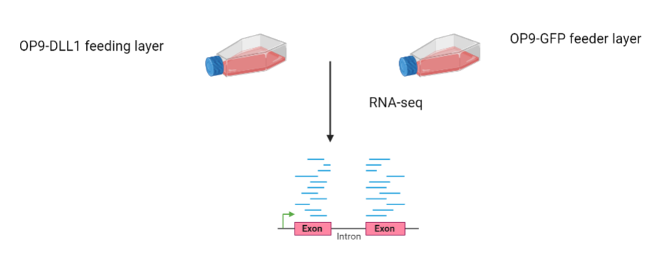

Diseño experimental

## Análisis de expresión diferencial

Este análisis de expresion diferencial se realizó utilizando Bioconductor.

Para el análisis de expresión diferencial se utilizaron datos obtenidos de Recount3, con el identificador SRP048604. Las lecturas fueron reescaladas utilizando funciones del paquete Recount3. Se realizaron análisis exploratorios del objeto RangeSummarizedExperiment (RSE), así como la determinacion de algunos parámetros de calidad de las lecturas, tales como la proporción de lecturas asignadas a genes y la distribución de los valores de lecturas. Los datos anteriores fueron utilizados para descartar lecturas consideradas insignificantes. Posteriormente los datos fueron normalizados, un procedimiento que tiene como objetivo eliminar efectos técnicos sistemáticos (Robinson, M.D., et al (2010). Finalmente, se generó un modelo estadístico adecuado y se realizó el análisis de expresión diferencial utilizando el paquete Limma.

## Resultados

#### Análisis exploratorios

Los análisis exploratorios del objeto permitieron comprobar que sólo había dos réplicas de lecturas para cada condición, lo que verdaderamente podría impactar en la obtención de resultados.

#### Parámetros de calidad de las lecturas en el RSE previo al análisis

La determinación de la proporción de lecturas asignadas a genes permitió corroborrar que las lecturas eran representativas del transcriptoma del modelo usado. Este parámetro se obtuvo mediante la relacion del atributo con las cuentas totales asignadas a genes y el atributo con las cuentas totales. En la figura 1 se observa un histograma con la distribución de este parámetro.

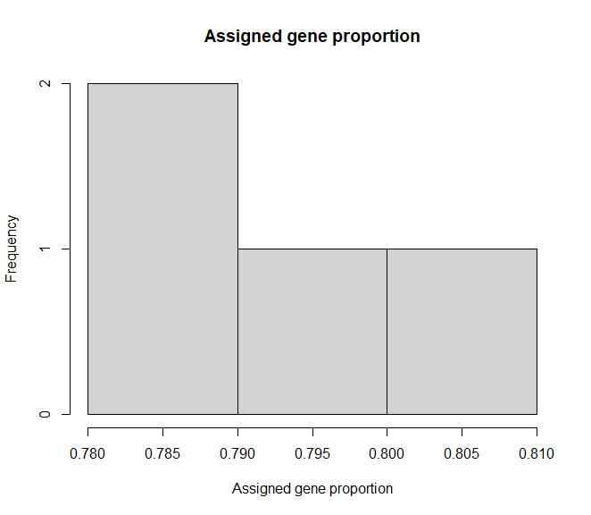

Figura 1. Proporcion de cuentas asignadas a genes

Asi mismo, los valores obtenidos por las cuentas mostraron la siguiente distribución de valores.

| Minimo | 1er quartil | Mediana | Media | 3er quartil | Máximo |
| --- | --- | --- | --- | --- | --- |
| 0.0 | 0.0 | 1.5 | 2095.0 | 197.0 | 1355387.2 |

#### Limpieza de los datos

La limpieza de los datos se fundamentó en los parámetros de calidad anteriores. Se eliminaron genes con una expresión por debajo de 0.1, quedando 61.89 % de genes restantes.

#### Analisis de expresión diferencial

Tras la limpieza y normalización de los datos, se procedió a establecer un modelo estadístico para la comparación de datos. Al tener una estructura muy sencilla (comparación tratamiento - control), no fue necesario utilizar visualizaciones gráficas como las que pudiera proporcionar el paquete de Bioconductor ExploreModelMatrix.

Finalmente, se realizó el análisis de expresión diferencial y se seleccionó aquellos genes con un valor P ajustado inferior a 0.05. Sin embargo, no se obtuvieron genes cuyo valor estuviera por debajo de este umbral, lo cual significa que la tasa de descubrimiento de falsos esta por encima del 5% y confiar en que los genes con un logFC (logaritmo de cambio duplicacion) alto son en realidad genes diferencialmente expresados (DEGs) es arriesgado.

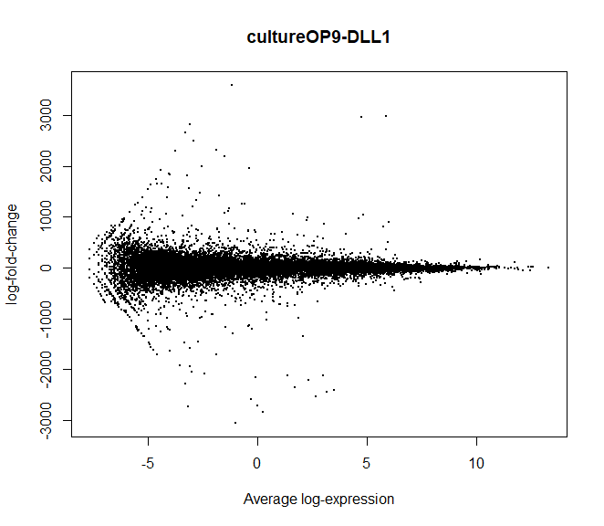

Figura 2. Grafica MA de DEGs bajo una activacion continua de NOTCH1

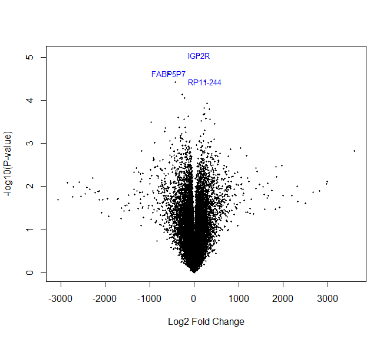

Figura 3. Grafica Volcal de DEGs bajo una activacion continua de NOTCH1

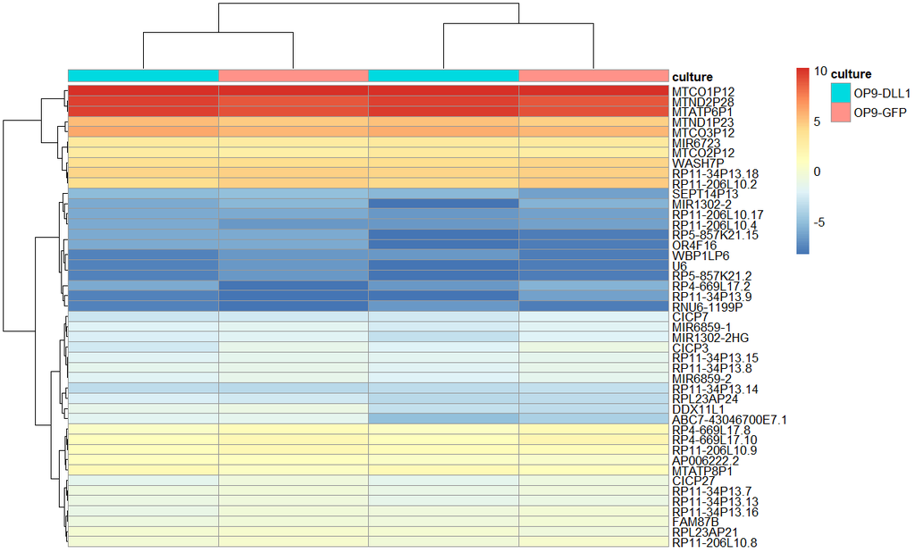

## Conclusiones y discusiones

Los resultados obtenidos del presente análisis de expresión diferencial no permitieron identificar con veracidad genes diferencialmente expresados, primordialmente por obtener valores p ajustados demasiado altos. Uno de los factores que influyeron en ello fue la cantidad de replicas disponibles para cada condición, las cuales son insuficientes para obtener datos estadísticamente significativos. Segun SCHURCH N. et al (2016), se recomienda al menos una cantidad de 6 replicas por condicion.

Dada la relevancia que podrían tener los resultados obtenidos de este análisis, sería recomendable repetir el experimento con una cantidad de replicas mayor a las recomendadas y ejecutar el análisis planteado en este reporte con esos nuevos datos.

## Bibliografias

1. Zhao, Y., Li, MC., Konaté, M.M. et al. TPM, FPKM, or Normalized Counts? A Comparative Study of Quantification Measures for the Analysis of RNA-seq Data from the NCI Patient-Derived Models Repository. J Transl Med 19, 269 (2021). https://doi.org/10.1186/s12967-021-02936-w
2. Schurch, N. J., Schofield, P., Gierliński, M., Cole, C., Sherstnev, A., Singh, V., ... & Barton, G. J. (2016). How many biological replicates are needed in an RNA-seq experiment and which differential expression tool should you use?. *Rna*, *22*(6), 839-851.
3. Robinson, M.D., Oshlack, A. A scaling normalization method for differential expression analysis of RNA-seq data. *Genome Biol* **11**, R25 (2010). https://doi.org/10.1186/gb-2010-11-3-r25